# Ford GoBike System Dataset Exploration

## Preliminary Wrangling

> This data set includes information about individual rides made in a bike-sharing system covering the greater San Francisco Bay area.

```python
# import all packages and set plots to be embedded inline
import numpy as np
import pandas as pd
import matplotlib.pyplot as plt
import seaborn as sb

%matplotlib inline
```

> Load in your dataset and describe its properties through the questions below. Try and motivate your exploration goals through this section.

```python
#load the data using pandas
go_bike_df = pd.read_csv("201902-fordgobike-tripdata.csv")
go_bike_df.head()
```

|  | duration_sec | start_time | end_time | start_station_id | start_station_name | start_station_latitude | start_station_longitude | end_station_id | end_station_name | end_station_latitude | end_station_longitude | bike_id | user_type | member_birth_year | member_gender | bike_share_for_all_trip |
| --- | --- | --- | --- | --- | --- | --- | --- | --- | --- | --- | --- | --- | --- | --- | --- | --- |
| 0 | 52185 | 2019-02-28 17:32:10.1450 | 2019-03-01 08:01:55.9750 | 21.0 | Montgomery St BART Station (Market St at 2nd St) | 37.789625 | -122.400811 | 13.0 | Commercial St at Montgomery St | 37.794231 | -122.402923 | 4902 | Customer | 1984.0 | Male | No |
| 1 | 42521 | 2019-02-28 18:53:21.7890 | 2019-03-01 06:42:03.0560 | 23.0 | The Embarcadero at Steuart St | 37.791464 | -122.391034 | 81.0 | Berry St at 4th St | 37.775880 | -122.393170 | 2535 | Customer | NaN | NaN | No |
| 2 | 61854 | 2019-02-28 12:13:13.2180 | 2019-03-01 05:24:08.1460 | 86.0 | Market St at Dolores St | 37.769305 | -122.426826 | 3.0 | Powell St BART Station (Market St at 4th St) | 37.786375 | -122.404904 | 5905 | Customer | 1972.0 | Male | No |
| 3 | 36490 | 2019-02-28 17:54:26.0100 | 2019-03-01 04:02:36.8420 | 375.0 | Grove St at Masonic Ave | 37.774836 | -122.446546 | 70.0 | Central Ave at Fell St | 37.773311 | -122.444293 | 6638 | Subscriber | 1989.0 | Other | No |
| 4 | 1585 | 2019-02-28 23:54:18.5490 | 2019-03-01 00:20:44.0740 | 7.0 | Frank H Ogawa Plaza | 37.804562 | -122.271738 | 222.0 | 10th Ave at E 15th St | 37.792714 | -122.248780 | 4898 | Subscriber | 1974.0 | Male | Yes |

```python
#a brief info about the dataframe
go_bike_df.info()
```

```
<class 'pandas.core.frame.DataFrame'>
RangeIndex: 183412 entries, 0 to 183411
Data columns (total 16 columns):
 #   Column                   Non-Null Count   Dtype
---  ------                   --------------   -----
 0   duration_sec             183412 non-null  int64
 1   start_time               183412 non-null  object
 2   end_time                 183412 non-null  object
 3   start_station_id         183215 non-null  float64
 4   start_station_name       183215 non-null  object
 5   start_station_latitude   183412 non-null  float64
 6   start_station_longitude  183412 non-null  float64
 7   end_station_id           183215 non-null  float64
 8   end_station_name         183215 non-null  object
 9   end_station_latitude     183412 non-null  float64
 10  end_station_longitude    183412 non-null  float64
 11  bike_id                  183412 non-null  int64
 12  user_type                183412 non-null  object
 13  member_birth_year        175147 non-null  float64
 14  member_gender            175147 non-null  object
 15  bike_share_for_all_trip  183412 non-null  object
dtypes: float64(7), int64(2), object(7)
memory usage: 22.4+ MB
```

As we can see start_time and end_time are from type object which will not grant us much use, we will simply convert them to datetime64 for more usefull tools later on

also we will convert the duration_sec into new column duratuin_hour, to be easily readable

```python
#convert the dtype of the columns start_time & end_time to => datetime64[ns]
go_bike_df["start_time"] = go_bike_df["start_time"].astype("datetime64[ns]")
go_bike_df["end_time"] = go_bike_df["end_time"].astype("datetime64[ns]")
```

```python
#create a new column that will help us in the analysis process
go_bike_df["duration_hour"] = go_bike_df["duration_sec"] / 3600 # Dividing by 3600 to convert seconds to hours
go_bike_df["duration_hour"]
```

```
0         14.495833
1         11.811389
2         17.181667
3         10.136111
4          0.440278
            ...
183407     0.133333
183408     0.086944
183409     0.039167
183410     0.038611
183411     0.075278
Name: duration_hour, Length: 183412, dtype: float64
```

```python
go_bike_df.info()
```

```
<class 'pandas.core.frame.DataFrame'>
RangeIndex: 183412 entries, 0 to 183411
Data columns (total 17 columns):
 #   Column                   Non-Null Count   Dtype
---  ------                   --------------   -----
 0   duration_sec             183412 non-null  int64
 1   start_time               183412 non-null  datetime64[ns]
 2   end_time                 183412 non-null  datetime64[ns]
 3   start_station_id         183215 non-null  float64
 4   start_station_name       183215 non-null  object
 5   start_station_latitude   183412 non-null  float64
 6   start_station_longitude  183412 non-null  float64
 7   end_station_id           183215 non-null  float64
 8   end_station_name         183215 non-null  object
 9   end_station_latitude     183412 non-null  float64
 10  end_station_longitude    183412 non-null  float64
 11  bike_id                  183412 non-null  int64
 12  user_type                183412 non-null  object
 13  member_birth_year        175147 non-null  float64
 14  member_gender            175147 non-null  object
 15  bike_share_for_all_trip  183412 non-null  object
 16  duration_hour            183412 non-null  float64
dtypes: datetime64[ns](2), float64(8), int64(2), object(5)
memory usage: 23.8+ MB
```

```python
go_bike_df.describe()
```

|  | duration_sec | start_station_id | start_station_latitude | start_station_longitude | end_station_id | end_station_latitude | end_station_longitude | bike_id | member_birth_year | duration_hour |
| --- | --- | --- | --- | --- | --- | --- | --- | --- | --- | --- |
| count | 183412.000000 | 183215.000000 | 183412.000000 | 183412.000000 | 183215.000000 | 183412.000000 | 183412.000000 | 183412.000000 | 175147.000000 | 183412.000000 |
| mean | 726.078435 | 138.590427 | 37.771223 | -122.352664 | 136.249123 | 37.771427 | -122.352250 | 4472.906375 | 1984.806437 | 0.201688 |
| std | 1794.389780 | 111.778864 | 0.099581 | 0.117097 | 111.515131 | 0.099490 | 0.116673 | 1664.383394 | 10.116689 | 0.498442 |
| min | 61.000000 | 3.000000 | 37.317298 | -122.453704 | 3.000000 | 37.317298 | -122.453704 | 11.000000 | 1878.000000 | 0.016944 |
| 25% | 325.000000 | 47.000000 | 37.770083 | -122.412408 | 44.000000 | 37.770407 | -122.411726 | 3777.000000 | 1980.000000 | 0.090278 |
| 50% | 514.000000 | 104.000000 | 37.780760 | -122.398285 | 100.000000 | 37.781010 | -122.398279 | 4958.000000 | 1987.000000 | 0.142778 |
| 75% | 796.000000 | 239.000000 | 37.797280 | -122.286533 | 235.000000 | 37.797320 | -122.288045 | 5502.000000 | 1992.000000 | 0.221111 |
| max | 85444.000000 | 398.000000 | 37.880222 | -121.874119 | 398.000000 | 37.880222 | -121.874119 | 6645.000000 | 2001.000000 | 23.734444 |

```python
go_bike_df["start_time"].dt.hour
```

```
0         17
1         18
2         12
3         17
4         23
          ..
183407     0
183408     0
183409     0
183410     0
183411     0
Name: start_time, Length: 183412, dtype: int64
```

```python
go_bike_df["end_time"].dt.hour
```

```
0         8
1         6
2         5
3         4
4         0
         ..
183407    0
183408    0
183409    0
183410    0
183411    0
Name: end_time, Length: 183412, dtype: int64
```

we can see that the min member_birth_year is 1878 which can not be possable so we can do some snippin to clean the data for more accurate results

we can also create a new column called member_age to easily identify the age of the biker

```python
#clear the dataframe by dropping rows that have member_birth_year lower that 1940
go_bike_df = go_bike_df[go_bike_df["member_birth_year"] > 1940]
```

```python
#create a new column that will help us in the analysis process
go_bike_df["member_age"] = 2021 - go_bike_df["member_birth_year"] # 2021 minus the member birth year will give us thier approximate age
go_bike_df["member_age"]
```

```
0         37.0
2         49.0
3         32.0
4         47.0
5         62.0
          ...
183407    25.0
183408    37.0
183409    31.0
183410    33.0
183411    32.0
Name: member_age, Length: 174944, dtype: float64
```

```python
go_bike_df.describe()
```

|  | duration_sec | start_station_id | start_station_latitude | start_station_longitude | end_station_id | end_station_latitude | end_station_longitude | bike_id | member_birth_year | duration_hour | member_age |
| --- | --- | --- | --- | --- | --- | --- | --- | --- | --- | --- | --- |
| count | 174944.000000 | 174749.000000 | 174944.000000 | 174944.000000 | 174749.000000 | 174944.000000 | 174944.000000 | 174944.000000 | 174944.000000 | 174944.000000 | 174944.000000 |
| mean | 704.509574 | 139.024092 | 37.770794 | -122.351263 | 136.643683 | 37.770989 | -122.350839 | 4481.980182 | 1984.880888 | 0.195697 | 36.119112 |
| std | 1642.477572 | 111.651112 | 0.101124 | 0.118499 | 111.352470 | 0.101031 | 0.118064 | 1658.354801 | 9.869501 | 0.456244 | 9.869501 |
| min | 61.000000 | 3.000000 | 37.317298 | -122.453704 | 3.000000 | 37.317298 | -122.453704 | 11.000000 | 1941.000000 | 0.016944 | 20.000000 |
| 25% | 323.000000 | 47.000000 | 37.770407 | -122.411901 | 44.000000 | 37.770407 | -122.411647 | 3802.000000 | 1980.000000 | 0.089722 | 29.000000 |
| 50% | 511.000000 | 104.000000 | 37.780760 | -122.398279 | 101.000000 | 37.781010 | -122.397405 | 4959.000000 | 1987.000000 | 0.141944 | 34.000000 |
| 75% | 789.000000 | 239.000000 | 37.797320 | -122.282497 | 238.000000 | 37.797673 | -122.285171 | 5505.000000 | 1992.000000 | 0.219167 | 41.000000 |
| max | 84548.000000 | 398.000000 | 37.880222 | -121.874119 | 398.000000 | 37.880222 | -121.874119 | 6645.000000 | 2001.000000 | 23.485556 | 80.000000 |

```python
go_bike_df.info()
```

```
<class 'pandas.core.frame.DataFrame'>
Int64Index: 174944 entries, 0 to 183411
Data columns (total 18 columns):
 #   Column                   Non-Null Count   Dtype
---  ------                   --------------   -----
 0   duration_sec             174944 non-null  int64
 1   start_time               174944 non-null  datetime64[ns]
 2   end_time                 174944 non-null  datetime64[ns]
 3   start_station_id         174749 non-null  float64
 4   start_station_name       174749 non-null  object
 5   start_station_latitude   174944 non-null  float64
 6   start_station_longitude  174944 non-null  float64
 7   end_station_id           174749 non-null  float64
 8   end_station_name         174749 non-null  object
 9   end_station_latitude     174944 non-null  float64
 10  end_station_longitude    174944 non-null  float64
 11  bike_id                  174944 non-null  int64
 12  user_type                174944 non-null  object
 13  member_birth_year        174944 non-null  float64
 14  member_gender            174944 non-null  object
 15  bike_share_for_all_trip  174944 non-null  object
 16  duration_hour            174944 non-null  float64
 17  member_age               174944 non-null  float64
dtypes: datetime64[ns](2), float64(9), int64(2), object(5)
memory usage: 25.4+ MB
```

### What is the structure of your dataset?

```
    - trip info duration_sec, start_time, end_time
    - member info member_birth_year member_gender
    - station info start_station_id start_station_name start_station_latitude start_station_longitude end_station_id
    end_station_name end_station_latitude end_station_longitude
    - added info to help in the analysis process member_age duration_hour
```

### What is/are the main feature(s) of interest in your dataset?

> main features are start-end time of the trip to help estimate the times were members use our service, the duration of the trip ,the gender of the member, the type of the user, lastely the age of the members.

### What features in the dataset do you think will help support your investigation into your feature(s) of interest?

> start_time, end_time, duration_hour, member_age user_type member_gender

## Univariate Exploration

> I will start investigating the main features that i mentioned in the above article.

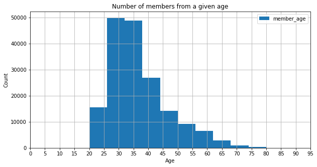

```python
#a plot for the number of members from a given age
go_bike_df[['member_age']].plot(kind='hist', figsize=(10,5), grid=True)
plt.title("Number of members from a given age")
plt.xticks(np.arange(20)*5)
plt.xlabel("Age")
plt.ylabel("Count")
plt.show()
```

by looking at the above plot we can see that the majority of our members are between 45-20, also our members peek between 30-35

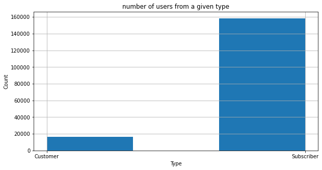

```python
#a plot for the number of users from a given type
plt.figure(figsize=(10,5))
go_bike_df['user_type'].hist(bins=3)
plt.title("number of users from a given type")
plt.xlabel("Type")
plt.ylabel("Count")
plt.show()
```

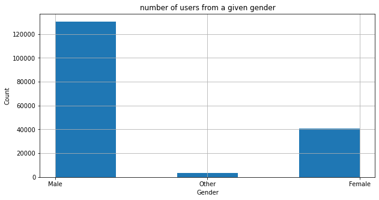

```python
#a plot for number of users from a given gender
plt.figure(figsize=(10,5))
go_bike_df['member_gender'].hist(bins=5)
plt.title("number of users from a given gender")
plt.xlabel("Gender")
plt.ylabel("Count")
plt.show()
```

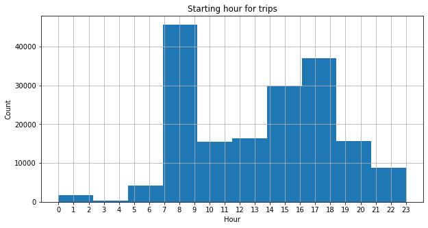

```python
#a plot for the starting hour for each trip
plt.figure(figsize=(10,5))
go_bike_df["start_time"].dt.hour.hist()
plt.title("Starting hour for trips")
plt.xticks(np.arange(24))
plt.xlabel("Hour")
plt.ylabel("Count")
plt.show()
```

by looking at the above histogram we can see that the majority of our trips start at 7AM and 5PM

```python
def plotinfo(title, ticks, xlabel, ylabel):
    plt.title(title)
    plt.xticks(ticks)
    plt.xlabel(xlabel)
    plt.ylabel(ylabel)
```

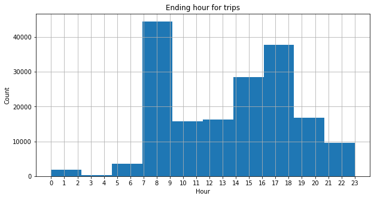

```python
#a plot for the ending hour of each trip
plt.figure(figsize=(10,5))
go_bike_df["end_time"].dt.hour.hist()
plotinfo("Ending hour for trips", np.arange(24), "Hour", "Count")
plt.show()
```

by lookin at the above histogram we can see that the end time is fairly simmilar to the start time, my geuss is that it is this way because most of the trips are about an hour or so, but we can see after plotting the duration of our trips

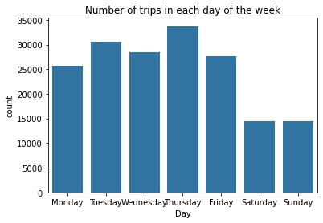

```python
#a plot for each trip for a given day
day_order = ["Monday", "Tuesday", "Wednesday", "Thursday", "Friday", "Saturday", "Sunday"]
sb.countplot(x = go_bike_df.start_time.dt.day_name(), data = go_bike_df, order = day_order, color=sb.color_palette()[0])
plt.xlabel("Day")
plt.title("Number of trips in each day of the week")
```

we can see that week-ends have lower trips

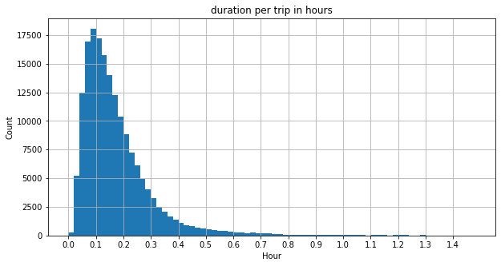

```python
#a plot for duration per trip in hours
bins = np.arange(0, 1.5, 0.02)
ticks = np.arange(0, 1.5, 0.1)
plt.figure(figsize=(10,5))
go_bike_df["duration_hour"].hist(bins=bins)
plt.title("duration per trip in hours")
plt.xticks(ticks)
plt.xlabel("Hour")
plt.ylabel("Count")
plt.show()
```

looking at this graph it explains why the end_time and the start_time looked similur, majority of trips were between 0.01h to 0.25h

### Discuss the distribution(s) of your variable(s) of interest. Were there any unusual points? Did you need to perform any transformations?

> as we saw, most of our customers were members, and most of our members were men, the age of our members varies from 20-45, people usually take our product to get from and to work, since the start times were usually at 7AM or 5PM, also they don't spend much time on the trip.

### Of the features you investigated, were there any unusual distributions? Did you perform any operations on the data to tidy, adjust, or change the form of the data? If so, why did you do this?

> on the duration_hour histogram, i had to scale the graph to little vlause using xticks and bins to be able to see the difference in the distribution of the data

## Bivariate Exploration

> i will start migrating some features togther to see the relation between them and plot them

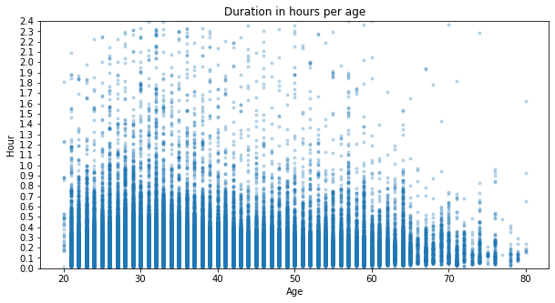

```python
#a plot for duration in hours per age
ticks = np.arange(0, 2.5, 0.1)
plt.figure(figsize=(10,5))
plt.ylim(ymin=0)
plt.yticks(ticks)
plt.scatter(go_bike_df["member_age"], go_bike_df["duration_hour"], alpha=0.25, marker=".")
plt.title("Duration in hours per age")
plt.xlabel("Age")
plt.ylabel("Hour")
plt.show()
```

Here we can see that membere from age 20-60 take trips in duration for around 0.1-1 Hour

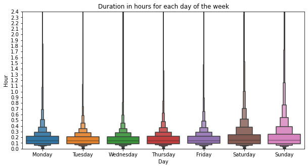

```python
#a plot for duration in hours for each day in the week
day = go_bike_df["start_time"].dt.day_name()
day_order = ["Monday", "Tuesday", "Wednesday", "Thursday", "Friday", "Saturday", "Sunday"]
ticks = np.arange(0, 2.5, 0.1)
plt.figure(figsize=(10,5))
plt.ylim(ymin=0)
plt.yticks(ticks)
sb.boxenplot(x=go_bike_df.start_time.dt.day_name(),y=go_bike_df.duration_hour, order=day_order)
plt.title("Duration in hours for each day of the week")
plt.xlabel("Day")
plt.ylabel("Hour")
plt.show()
```

even though the week-ends effect the amount of trips (as we saw in previuos graphs) the duration is fairly the same

### Did you observe any interesting relationships between the other features (not the main feature(s) of interest)?

> as we observed in the second grapgh, i was surprised when i saw that duration of the trips stayed fairly the same throughout the week

## Multivariate Exploration

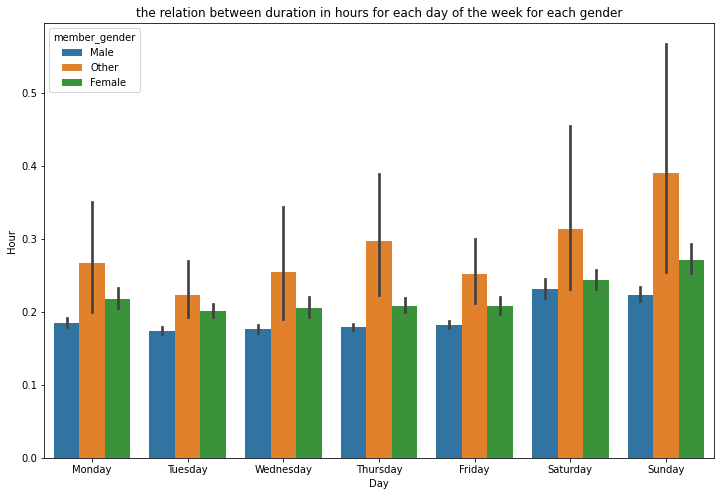

```python
#a plot to show the relation between duration in hours for each day of the week for each gender
day_order = ["Monday", "Tuesday", "Wednesday", "Thursday", "Friday", "Saturday", "Sunday"]
plt.figure(figsize=(12,8))
sb.barplot(x=go_bike_df.start_time.dt.day_name(), y= go_bike_df.duration_hour, hue=go_bike_df.member_gender, data=go_bike_df, order=day_order)
plt.title("the relation between duration in hours for each day of the week for each gender")
plt.xlabel("Day")
plt.ylabel("Hour")
plt.show()
```

"Other" gender seem to be standing out in this plot, on average it seems like they take more duration than the others

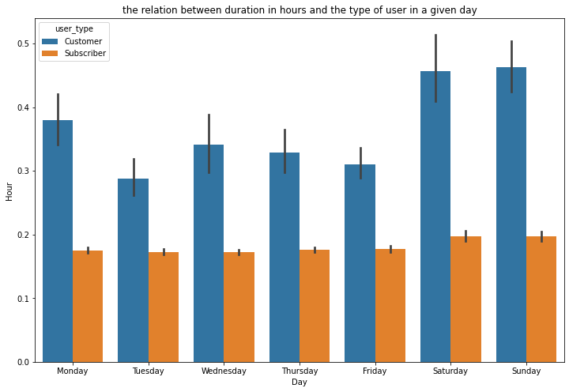

```python
#a plot to show the relation between duration in hours and the type of user in a given day
day_order = ["Monday", "Tuesday", "Wednesday", "Thursday", "Friday", "Saturday", "Sunday"]

plt.figure(figsize=(12,8))
sb.barplot(x=go_bike_df.start_time.dt.day_name(), y= go_bike_df.duration_hour, hue=go_bike_df.user_type, data=go_bike_df, order=day_order);
plt.title("the relation between duration in hours and the type of user in a given day")
plt.xlabel("Day")
plt.ylabel("Hour")
plt.show()
```

"Customers" seem to be standing out in this plot, on average it seems like they take more duration than the Subscribers

### Talk about some of the relationships you observed in this part of the investigation. Were there features that strengthened each other in terms of looking at your feature(s) of interest?

> as we have observed, the gender "other" on average spend more time on trips, it not extreme by any mean but its worth mentioning